# 0a26d27e-156c-4de8-a653-c819e4ef8a53

## Шаг 1. Откройте файл с данными и изучите общую информацию

```python
import pandas as pd
import numpy as np
import matplotlib.pyplot as plt
import math
from IPython.display import display
from scipy import stats as st

data_calls = pd.read_csv('/datasets/calls.csv')
data_internet = pd.read_csv('/datasets/internet.csv')
data_messages = pd.read_csv('/datasets/messages.csv')
data_tariffs = pd.read_csv('/datasets/tariffs.csv')
data_users = pd.read_csv('/datasets/users.csv')
```

```python
data_calls.info()
```

```
<class 'pandas.core.frame.DataFrame'>
RangeIndex: 202607 entries, 0 to 202606
Data columns (total 4 columns):
id           202607 non-null object
call_date    202607 non-null object
duration     202607 non-null float64
user_id      202607 non-null int64
dtypes: float64(1), int64(1), object(2)
memory usage: 6.2+ MB
```

```python
data_internet.info()
```

```
<class 'pandas.core.frame.DataFrame'>
RangeIndex: 149396 entries, 0 to 149395
Data columns (total 5 columns):
Unnamed: 0      149396 non-null int64
id              149396 non-null object
mb_used         149396 non-null float64
session_date    149396 non-null object
user_id         149396 non-null int64
dtypes: float64(1), int64(2), object(2)
memory usage: 5.7+ MB
```

```python
data_messages.info()
```

```
<class 'pandas.core.frame.DataFrame'>
RangeIndex: 123036 entries, 0 to 123035
Data columns (total 3 columns):
id              123036 non-null object
message_date    123036 non-null object
user_id         123036 non-null int64
dtypes: int64(1), object(2)
memory usage: 2.8+ MB
```

```python
data_tariffs.info()
```

```
<class 'pandas.core.frame.DataFrame'>
RangeIndex: 2 entries, 0 to 1
Data columns (total 8 columns):
messages_included        2 non-null int64
mb_per_month_included    2 non-null int64
minutes_included         2 non-null int64
rub_monthly_fee          2 non-null int64
rub_per_gb               2 non-null int64
rub_per_message          2 non-null int64
rub_per_minute           2 non-null int64
tariff_name              2 non-null object
dtypes: int64(7), object(1)
memory usage: 256.0+ bytes
```

```python
data_users.info()
```

```
<class 'pandas.core.frame.DataFrame'>
RangeIndex: 500 entries, 0 to 499
Data columns (total 8 columns):
user_id       500 non-null int64
age           500 non-null int64
churn_date    38 non-null object
city          500 non-null object
first_name    500 non-null object
last_name     500 non-null object
reg_date      500 non-null object
tariff        500 non-null object
dtypes: int64(2), object(6)
memory usage: 31.4+ KB
```

## Вывод

Данные распределены по пяти датасетам: `data_calls`, `data_internet`, `data_messages`, `data_tariffs`, `data_users`. Названия столбцов не требуют изменений.

Датасет `data_calls` состоит из 4 столбцов и 202607 строк. Столбец `call_date` необходимо привести к формату даты.

Датасет `data_internet` состоит из 5 столбцов и 149396 строк. Столбец `session_date` необходимо привести к формату даты.

Датасет `data_messages` состоит из 3 столбцов и 123036 строк. Столбец `message_date` необходимо привести к формату даты.

Датасет `data_users` состоит из 8 столбцов и 500 строк. Столбцы `churn_date` и `reg_date` необходимо привести к формату даты. Столбец `churn_date` содержит 462 нулевых значения. Это означает, что пользователи ещё пользуются тарифом.

Датасеты `data_calls`, `data_internet`, `data_messages`, `data_users` связаны по `user_id`.

Датасет `data_tariffs` состоит из 8 столбцов и 2 строк и содержит информацию о тарифах.

## Шаг 2. Подготовьте данные

Приведем строки в столбце `call_date` таблицы `data_calls` к формату даты и добавим столбец месяца `call_month`.

```python
data_calls['call_date'] = pd.to_datetime(data_calls['call_date'], format='%Y-%m-%d')
data_calls['call_month'] = data_calls['call_date'].dt.month
```

Округлим вверх значения минут за исключением тех, чья длительность — 0.0. Для этого выберем из таблицы все значения кроме нулевых, отбросим дробную часть методом `np.floor` и прибавим единицу. Сохраним результат в столбце `duration_minute`.

```python
data_calls['duration_minute'] = data_calls['duration']
data_calls.loc[data_calls['duration_minute'] != 0, 'duration_minute'] = data_calls.loc[data_calls['duration_minute'] != 0, \
                                                                                 'duration_minute'].apply(np.floor) + 1
data_calls.head(10)
```

|  | id | call_date | duration | user_id | call_month | duration_minute |
| --- | --- | --- | --- | --- | --- | --- |
| 0 | 1000_0 | 2018-07-25 | 0.00 | 1000 | 7 | 0.0 |
| 1 | 1000_1 | 2018-08-17 | 0.00 | 1000 | 8 | 0.0 |
| 2 | 1000_2 | 2018-06-11 | 2.85 | 1000 | 6 | 3.0 |
| 3 | 1000_3 | 2018-09-21 | 13.80 | 1000 | 9 | 14.0 |
| 4 | 1000_4 | 2018-12-15 | 5.18 | 1000 | 12 | 6.0 |
| 5 | 1000_5 | 2018-11-02 | 0.00 | 1000 | 11 | 0.0 |
| 6 | 1000_6 | 2018-10-18 | 0.00 | 1000 | 10 | 0.0 |
| 7 | 1000_7 | 2018-08-22 | 18.31 | 1000 | 8 | 19.0 |
| 8 | 1000_8 | 2018-09-15 | 18.44 | 1000 | 9 | 19.0 |
| 9 | 1000_9 | 2018-08-15 | 0.00 | 1000 | 8 | 0.0 |

Построим гистограмму округленной длительности звонка в минутах.

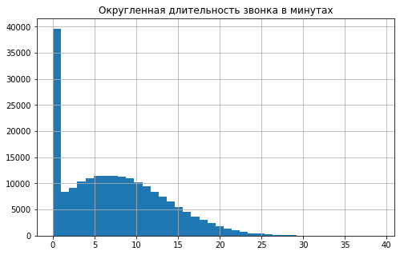

```python
data_calls['duration_minute'].hist(bins=len(data_calls['duration_minute'].value_counts()), figsize=(8, 5))
plt.title('Округленная длительность звонка в минутах');
```

Поскольку нулевые значения не влияют на выручку пользователей, оставим их в датасете. Максимальная длительность звонка не превышает 40 минут, что не является аномалией.

Посчитаем количество сделанных звонков по месяцам. Для этого создадим сводную таблицу `data_calls_pivot_count`, сгруппировав количество звонков по пользователям и месяцам.

```python
data_calls_pivot_count = data_calls.pivot_table(index='user_id', columns='call_month', \
                                                values='id', aggfunc='count').fillna(0)
data_calls_pivot_count.head()
```

| call_month user_id | 1 | 2 | 3 | 4 | 5 | 6 | 7 | 8 | 9 | 10 | 11 | 12 |
| --- | --- | --- | --- | --- | --- | --- | --- | --- | --- | --- | --- | --- |
| 1000 | 0.0 | 0.0 | 0.0 | 0.0 | 22.0 | 43.0 | 47.0 | 52.0 | 58.0 | 57.0 | 43.0 | 46.0 |
| 1001 | 0.0 | 0.0 | 0.0 | 0.0 | 0.0 | 0.0 | 0.0 | 0.0 | 0.0 | 0.0 | 59.0 | 63.0 |
| 1002 | 0.0 | 0.0 | 0.0 | 0.0 | 0.0 | 15.0 | 26.0 | 42.0 | 36.0 | 33.0 | 32.0 | 33.0 |
| 1003 | 0.0 | 0.0 | 0.0 | 0.0 | 0.0 | 0.0 | 0.0 | 55.0 | 134.0 | 108.0 | 115.0 | 108.0 |
| 1004 | 0.0 | 0.0 | 0.0 | 0.0 | 9.0 | 31.0 | 22.0 | 19.0 | 26.0 | 29.0 | 19.0 | 21.0 |

Посчитаем количество израсходованных минут разговора по месяцам. Для этого создадим сводную таблицу `data_calls_pivot`, сгруппировав количество звонков по пользователям и месяцам и посчитав суммарное количество минут разговора.

```python
data_calls_pivot = data_calls.pivot_table(index='user_id', columns='call_month', \
                                              values='duration_minute', aggfunc='sum').fillna(0)
data_calls_pivot.head()
```

| call_month user_id | 1 | 2 | 3 | 4 | 5 | 6 | 7 | 8 | 9 | 10 | 11 | 12 |
| --- | --- | --- | --- | --- | --- | --- | --- | --- | --- | --- | --- | --- |
| 1000 | 0.0 | 0.0 | 0.0 | 0.0 | 159.0 | 172.0 | 340.0 | 409.0 | 467.0 | 350.0 | 338.0 | 333.0 |
| 1001 | 0.0 | 0.0 | 0.0 | 0.0 | 0.0 | 0.0 | 0.0 | 0.0 | 0.0 | 0.0 | 430.0 | 414.0 |
| 1002 | 0.0 | 0.0 | 0.0 | 0.0 | 0.0 | 117.0 | 214.0 | 291.0 | 207.0 | 212.0 | 243.0 | 236.0 |
| 1003 | 0.0 | 0.0 | 0.0 | 0.0 | 0.0 | 0.0 | 0.0 | 380.0 | 961.0 | 856.0 | 824.0 | 802.0 |
| 1004 | 0.0 | 0.0 | 0.0 | 0.0 | 35.0 | 171.0 | 135.0 | 137.0 | 117.0 | 146.0 | 118.0 | 130.0 |

Приведем строки в столбце `message_date` таблицы `data_messages` к формату даты и добавим столбец месяца `message_month`.

```python
data_messages['message_date'] = pd.to_datetime(data_messages['message_date'], format='%Y-%m-%d')
data_messages['message_month'] = data_messages['message_date'].dt.month
```

Посчитаем количество отправленных сообщений по месяцам. Для этого создадим сводную таблицу `data_messages_pivot_sum`, сгруппировав количество сообщений по пользователям и месяцам и посчитав количество сообщений.

```python
data_messages_pivot = data_messages.pivot_table(index='user_id', columns='message_month', \
                                                values='id', aggfunc='count').fillna(0)
data_messages_pivot.head()
```

| message_month user_id | 1 | 2 | 3 | 4 | 5 | 6 | 7 | 8 | 9 | 10 | 11 | 12 |
| --- | --- | --- | --- | --- | --- | --- | --- | --- | --- | --- | --- | --- |
| 1000 | 0.0 | 0.0 | 0.0 | 0.0 | 22.0 | 60.0 | 75.0 | 81.0 | 57.0 | 73.0 | 58.0 | 70.0 |
| 1002 | 0.0 | 0.0 | 0.0 | 0.0 | 0.0 | 4.0 | 11.0 | 13.0 | 4.0 | 10.0 | 16.0 | 12.0 |
| 1003 | 0.0 | 0.0 | 0.0 | 0.0 | 0.0 | 0.0 | 0.0 | 37.0 | 91.0 | 83.0 | 94.0 | 75.0 |
| 1004 | 0.0 | 0.0 | 0.0 | 0.0 | 95.0 | 134.0 | 181.0 | 151.0 | 146.0 | 165.0 | 158.0 | 162.0 |
| 1005 | 7.0 | 38.0 | 56.0 | 41.0 | 42.0 | 47.0 | 56.0 | 64.0 | 52.0 | 44.0 | 51.0 | 54.0 |

Приведем строки в столбце `session_date` таблицы `data_internet` к формату даты и добавим столбец месяца `session_month`.

```python
data_internet['session_date'] = pd.to_datetime(data_internet['session_date'], format='%Y-%m-%d')
data_internet['session_month'] = data_internet['session_date'].dt.month
```

Округлим вверх значения мегабайт за исключением тех, чей объём — 0.0. Для этого выберем из таблицы все значения кроме нулевых, отбросим дробную часть методом `np.floor` и прибавим единицу. Сохраним результат в столбце `mb_used_int`.

```python
data_internet['mb_used_int'] = data_internet['mb_used']
data_internet.loc[data_internet['mb_used_int'] != 0, 'mb_used_int'] = data_internet.loc[data_internet['mb_used_int'] != 0, \
                                                                                 'mb_used_int'].apply(np.floor) + 1
data_internet
```

|  | Unnamed: 0 | id | mb_used | session_date | user_id | session_month | mb_used_int |
| --- | --- | --- | --- | --- | --- | --- | --- |
| 0 | 0 | 1000_0 | 112.95 | 2018-11-25 | 1000 | 11 | 113.0 |
| 1 | 1 | 1000_1 | 1052.81 | 2018-09-07 | 1000 | 9 | 1053.0 |
| 2 | 2 | 1000_2 | 1197.26 | 2018-06-25 | 1000 | 6 | 1198.0 |
| 3 | 3 | 1000_3 | 550.27 | 2018-08-22 | 1000 | 8 | 551.0 |
| 4 | 4 | 1000_4 | 302.56 | 2018-09-24 | 1000 | 9 | 303.0 |
| ... | ... | ... | ... | ... | ... | ... | ... |
| 149391 | 149391 | 1499_152 | 318.90 | 2018-10-03 | 1499 | 10 | 319.0 |
| 149392 | 149392 | 1499_153 | 490.13 | 2018-12-14 | 1499 | 12 | 491.0 |
| 149393 | 149393 | 1499_154 | 0.00 | 2018-10-27 | 1499 | 10 | 0.0 |
| 149394 | 149394 | 1499_155 | 1246.32 | 2018-11-26 | 1499 | 11 | 1247.0 |
| 149395 | 149395 | 1499_156 | 544.37 | 2018-10-26 | 1499 | 10 | 545.0 |

149396 rows × 7 columns

Построим гистограмму округлённого объёма интернет-трафика (в мегабайтах).

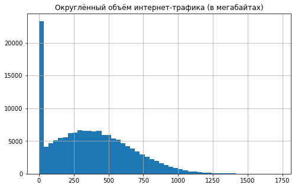

```python
data_internet['mb_used_int'].hist(bins=50, figsize=(8, 5))
plt.title('Округлённый объём интернет-трафика (в мегабайтах)');
```

Поскольку нулевые значения не влияют на выручку пользователей, оставим их в датасете. Максимальный объём потраченного за сессию интернет-трафика не превышает двух гигабайт, что не является уникальным.

Посчитаем объём израсходованного интернет-трафика по месяцам. Для этого создадим сводную таблицу `data_internet_pivot_sum`, сгруппировав объём интернет-трафика по пользователям по месяцам и посчитав суммарный объём интернет-трафика.

```python
data_internet_pivot = data_internet.pivot_table(index='user_id', columns='session_month', \
                                                    values='mb_used_int', aggfunc='sum').fillna(0)
data_internet_pivot.head()
```

| session_month user_id | 1 | 2 | 3 | 4 | 5 | 6 | 7 | 8 | 9 | 10 | 11 | 12 |
| --- | --- | --- | --- | --- | --- | --- | --- | --- | --- | --- | --- | --- |
| 1000 | 0.0 | 0.0 | 0.0 | 0.0 | 2256.0 | 23257.0 | 14016.0 | 14070.0 | 14581.0 | 14717.0 | 14768.0 | 9827.0 |
| 1001 | 0.0 | 0.0 | 0.0 | 0.0 | 0.0 | 0.0 | 0.0 | 0.0 | 0.0 | 0.0 | 18452.0 | 14053.0 |
| 1002 | 0.0 | 0.0 | 0.0 | 0.0 | 0.0 | 10871.0 | 17601.0 | 20348.0 | 16713.0 | 13905.0 | 18610.0 | 18139.0 |
| 1003 | 0.0 | 0.0 | 0.0 | 0.0 | 0.0 | 0.0 | 0.0 | 8571.0 | 12479.0 | 14779.0 | 11368.0 | 10132.0 |
| 1004 | 0.0 | 0.0 | 0.0 | 0.0 | 13416.0 | 17619.0 | 22243.0 | 28608.0 | 15125.0 | 18494.0 | 15631.0 | 18039.0 |

Приведем строки в столбцах `reg_date` и `churn_date` таблицы `data_users` к формату даты и добавим столбцы месяца `reg_date_month` и `churn_date_month`. Заменим значения `NaN` в столбце `churn_date_month` на 13 (значит тариф ещё действует).

```python
data_users['reg_date'] = pd.to_datetime(data_users['reg_date'], format='%Y-%m-%d')
data_users['reg_date_month'] = data_users['reg_date'].dt.month

data_users['churn_date'] = pd.to_datetime(data_users['churn_date'], format='%Y-%m-%d')
data_users['churn_date_month'] = data_users['churn_date'].dt.month

data_users['churn_date_month'] = data_users['churn_date_month'].fillna(13)
data_users
```

|  | user_id | age | churn_date | city | first_name | last_name | reg_date | tariff | reg_date_month | churn_date_month |
| --- | --- | --- | --- | --- | --- | --- | --- | --- | --- | --- |
| 0 | 1000 | 52 | NaT | Краснодар | Рафаил | Верещагин | 2018-05-25 | ultra | 5 | 13.0 |
| 1 | 1001 | 41 | NaT | Москва | Иван | Ежов | 2018-11-01 | smart | 11 | 13.0 |
| 2 | 1002 | 59 | NaT | Стерлитамак | Евгений | Абрамович | 2018-06-17 | smart | 6 | 13.0 |
| 3 | 1003 | 23 | NaT | Москва | Белла | Белякова | 2018-08-17 | ultra | 8 | 13.0 |
| 4 | 1004 | 68 | NaT | Новокузнецк | Татьяна | Авдеенко | 2018-05-14 | ultra | 5 | 13.0 |
| ... | ... | ... | ... | ... | ... | ... | ... | ... | ... | ... |
| 495 | 1495 | 65 | NaT | Иркутск | Авксентий | Фокин | 2018-08-28 | ultra | 8 | 13.0 |
| 496 | 1496 | 36 | NaT | Вологда | Трифон | Блохин | 2018-01-27 | smart | 1 | 13.0 |
| 497 | 1497 | 32 | NaT | Челябинск | Каролина | Агеева | 2018-10-09 | smart | 10 | 13.0 |
| 498 | 1498 | 68 | 2018-10-25 | Владикавказ | Всеволод | Акимчин | 2018-07-19 | smart | 7 | 10.0 |
| 499 | 1499 | 35 | NaT | Пермь | Гектор | Корнилов | 2018-09-27 | smart | 9 | 13.0 |

500 rows × 10 columns

Создадим сводную таблицу `data_users_pivot`, где единицами будут отмечены месяцы подключения тарифа.

```python
data_users_pivot = data_users.pivot_table(index='user_id', columns='reg_date_month', \
                                                    values='tariff', aggfunc='count').fillna(0)
data_users_pivot.head()
```

| reg_date_month user_id | 1 | 2 | 3 | 4 | 5 | 6 | 7 | 8 | 9 | 10 | 11 | 12 |
| --- | --- | --- | --- | --- | --- | --- | --- | --- | --- | --- | --- | --- |
| 1000 | 0.0 | 0.0 | 0.0 | 0.0 | 1.0 | 0.0 | 0.0 | 0.0 | 0.0 | 0.0 | 0.0 | 0.0 |
| 1001 | 0.0 | 0.0 | 0.0 | 0.0 | 0.0 | 0.0 | 0.0 | 0.0 | 0.0 | 0.0 | 1.0 | 0.0 |
| 1002 | 0.0 | 0.0 | 0.0 | 0.0 | 0.0 | 1.0 | 0.0 | 0.0 | 0.0 | 0.0 | 0.0 | 0.0 |
| 1003 | 0.0 | 0.0 | 0.0 | 0.0 | 0.0 | 0.0 | 0.0 | 1.0 | 0.0 | 0.0 | 0.0 | 0.0 |
| 1004 | 0.0 | 0.0 | 0.0 | 0.0 | 1.0 | 0.0 | 0.0 | 0.0 | 0.0 | 0.0 | 0.0 | 0.0 |

Создадим сводную таблицу `data_users_zero`, заполненную нулями, она пригодится нам в дальнейшем.

```python
data_users_zero = data_users_pivot.replace(1, 0)
```

В цикле по каждому пользователю сравним каждый месяц с месяцем подключения тарифа и месяцем прекращения пользования тарифом. Если он внутри диапазона, меняем значение в сводной таблице на единицу.

```python
for i in range(data_users.shape[0]):
    for j in range(1,13):
        if (j >= data_users.loc[i, 'reg_date_month']) and (j <= data_users.loc[i, 'churn_date_month']):
            data_users_pivot.loc[1000+i, j] = 1
data_users_pivot.tail()
```

| reg_date_month user_id | 1 | 2 | 3 | 4 | 5 | 6 | 7 | 8 | 9 | 10 | 11 | 12 |
| --- | --- | --- | --- | --- | --- | --- | --- | --- | --- | --- | --- | --- |
| 1495 | 0.0 | 0.0 | 0.0 | 0.0 | 0.0 | 0.0 | 0.0 | 1.0 | 1.0 | 1.0 | 1.0 | 1.0 |
| 1496 | 1.0 | 1.0 | 1.0 | 1.0 | 1.0 | 1.0 | 1.0 | 1.0 | 1.0 | 1.0 | 1.0 | 1.0 |
| 1497 | 0.0 | 0.0 | 0.0 | 0.0 | 0.0 | 0.0 | 0.0 | 0.0 | 0.0 | 1.0 | 1.0 | 1.0 |
| 1498 | 0.0 | 0.0 | 0.0 | 0.0 | 0.0 | 0.0 | 1.0 | 1.0 | 1.0 | 1.0 | 0.0 | 0.0 |
| 1499 | 0.0 | 0.0 | 0.0 | 0.0 | 0.0 | 0.0 | 0.0 | 0.0 | 1.0 | 1.0 | 1.0 | 1.0 |

Чтобы найти помесячную выручку с каждого пользователя, преобразуем найденные сводные таблицы и просуммируем. Однако можно обнаружить, что они не одинаковы по размеру. Некоторые пользователи не совершают звонки, другие не отправляют сообщения, третьи не пользуются интернетом. Приведём их к единому образцу, сложив с нулевой таблицей `data_users_zero` и обнулив значения `NaN`.

```python
data_calls_pivot = (data_users_zero + data_calls_pivot).fillna(0)
data_messages_pivot = (data_users_zero + data_messages_pivot).fillna(0)
data_internet_pivot = (data_users_zero + data_internet_pivot).fillna(0)
```

Посчитаем помесячную выручку с каждого пользователя, как если бы он пользовался обоими тарифами. Сначала найдём стоимость интернет-трафика сверх тарифного пакета по тарифу «Смарт». Для этого вычтем из таблицы `data_internet_pivot` бесплатный лимит в 15 ГБ, обнулим отрицательные значения методом `mask()`, переведём в гигабайты, поделив на 1024, выберем все значения кроме нулевых, отбросим дробную часть методом `np.floor`, прибавим единицу и умножим на стоимость 1 Гб интернет-трафика сверх тарифа. Обнулим значения `NaN` и сохраним результат в таблице `pivot_data_smart`.

```python
pivot_data_smart = (data_internet_pivot - 15360).mask((data_internet_pivot - 15360) < 0, 0) / 1024
pivot_data_smart = (pivot_data_smart[pivot_data_smart != 0].apply(np.floor) + 1) * 200
pivot_data_smart = pivot_data_smart.fillna(0)
pivot_data_smart.head()
```

| reg_date_month user_id | 1 | 2 | 3 | 4 | 5 | 6 | 7 | 8 | 9 | 10 | 11 | 12 |
| --- | --- | --- | --- | --- | --- | --- | --- | --- | --- | --- | --- | --- |
| 1000 | 0.0 | 0.0 | 0.0 | 0.0 | 0.0 | 1600.0 | 0.0 | 0.0 | 0.0 | 0.0 | 0.0 | 0.0 |
| 1001 | 0.0 | 0.0 | 0.0 | 0.0 | 0.0 | 0.0 | 0.0 | 0.0 | 0.0 | 0.0 | 800.0 | 0.0 |
| 1002 | 0.0 | 0.0 | 0.0 | 0.0 | 0.0 | 0.0 | 600.0 | 1000.0 | 400.0 | 0.0 | 800.0 | 600.0 |
| 1003 | 0.0 | 0.0 | 0.0 | 0.0 | 0.0 | 0.0 | 0.0 | 0.0 | 0.0 | 0.0 | 0.0 | 0.0 |
| 1004 | 0.0 | 0.0 | 0.0 | 0.0 | 0.0 | 600.0 | 1400.0 | 2600.0 | 0.0 | 800.0 | 200.0 | 600.0 |

Затем вычислим абонентскую плату, вычтем бесплатный лимит из суммарного количества звонков и сообщений, обнулим отрицательные значения методом `mask()`, умножим остаток на значение из тарифного плана «Смарт», и прибавим к уже сохранённой в таблице `pivot_data_smart` стоимости интернет-трафика сверх тарифного пакета.

```python
pivot_data_smart = (
    data_users_pivot * 550 +
    (data_calls_pivot - 500).mask((data_calls_pivot - 500) < 0, 0) * 3 +
    (data_messages_pivot - 50).mask((data_messages_pivot - 50) < 0, 0) * 3 +
    pivot_data_smart
)
pivot_data_smart
```

| reg_date_month user_id | 1 | 2 | 3 | 4 | 5 | 6 | 7 | 8 | 9 | 10 | 11 | 12 |
| --- | --- | --- | --- | --- | --- | --- | --- | --- | --- | --- | --- | --- |
| 1000 | 0.0 | 0.0 | 0.0 | 0.0 | 550.0 | 2180.0 | 625.0 | 643.0 | 571.0 | 619.0 | 574.0 | 610.0 |
| 1001 | 0.0 | 0.0 | 0.0 | 0.0 | 0.0 | 0.0 | 0.0 | 0.0 | 0.0 | 0.0 | 1350.0 | 550.0 |
| 1002 | 0.0 | 0.0 | 0.0 | 0.0 | 0.0 | 550.0 | 1150.0 | 1550.0 | 950.0 | 550.0 | 1350.0 | 1150.0 |
| 1003 | 0.0 | 0.0 | 0.0 | 0.0 | 0.0 | 0.0 | 0.0 | 550.0 | 2056.0 | 1717.0 | 1654.0 | 1531.0 |
| 1004 | 0.0 | 0.0 | 0.0 | 0.0 | 685.0 | 1402.0 | 2343.0 | 3453.0 | 838.0 | 1695.0 | 1074.0 | 1486.0 |
| ... | ... | ... | ... | ... | ... | ... | ... | ... | ... | ... | ... | ... |
| 1495 | 0.0 | 0.0 | 0.0 | 0.0 | 0.0 | 0.0 | 0.0 | 550.0 | 5194.0 | 5039.0 | 6802.0 | 3854.0 |
| 1496 | 550.0 | 3435.0 | 2721.0 | 1819.0 | 2350.0 | 1715.0 | 2596.0 | 2431.0 | 2950.0 | 3150.0 | 3039.0 | 1807.0 |
| 1497 | 0.0 | 0.0 | 0.0 | 0.0 | 0.0 | 0.0 | 0.0 | 0.0 | 0.0 | 550.0 | 550.0 | 1685.0 |
| 1498 | 0.0 | 0.0 | 0.0 | 0.0 | 0.0 | 0.0 | 550.0 | 2386.0 | 1950.0 | 1750.0 | 0.0 | 0.0 |
| 1499 | 0.0 | 0.0 | 0.0 | 0.0 | 0.0 | 0.0 | 0.0 | 0.0 | 550.0 | 1150.0 | 1513.0 | 598.0 |

500 rows × 12 columns

Сбросим индексы таблицы `pivot_data_smart` и объединим её с таблицей `data_users` методом `merge()`. Выделим пользователей тарифа «Смарт» и сохраним их в таблицу `data_users_smart`.

```python
data_users_smart = data_users.merge(pivot_data_smart.reset_index()).query('tariff == "smart"')
data_users_smart
```

|  | user_id | age | churn_date | city | first_name | last_name | reg_date | tariff | reg_date_month | churn_date_month | ... | 3 | 4 | 5 | 6 | 7 | 8 | 9 | 10 | 11 | 12 |
| --- | --- | --- | --- | --- | --- | --- | --- | --- | --- | --- | --- | --- | --- | --- | --- | --- | --- | --- | --- | --- | --- |
| 1 | 1001 | 41 | NaT | Москва | Иван | Ежов | 2018-11-01 | smart | 11 | 13.0 | ... | 0.0 | 0.0 | 0.0 | 0.0 | 0.0 | 0.0 | 0.0 | 0.0 | 1350.0 | 550.0 |
| 2 | 1002 | 59 | NaT | Стерлитамак | Евгений | Абрамович | 2018-06-17 | smart | 6 | 13.0 | ... | 0.0 | 0.0 | 0.0 | 550.0 | 1150.0 | 1550.0 | 950.0 | 550.0 | 1350.0 | 1150.0 |
| 5 | 1005 | 67 | NaT | Набережные Челны | Афанасий | Горлов | 2018-01-25 | smart | 1 | 13.0 | ... | 892.0 | 1186.0 | 835.0 | 886.0 | 778.0 | 952.0 | 556.0 | 1219.0 | 706.0 | 838.0 |
| 6 | 1006 | 21 | NaT | Ульяновск | Леонид | Ермолаев | 2018-02-26 | smart | 2 | 13.0 | ... | 950.0 | 550.0 | 550.0 | 550.0 | 1550.0 | 1350.0 | 750.0 | 1550.0 | 550.0 | 1350.0 |
| 7 | 1007 | 65 | NaT | Москва | Юна | Березина | 2018-04-19 | smart | 4 | 13.0 | ... | 0.0 | 550.0 | 1150.0 | 688.0 | 984.0 | 1750.0 | 1018.0 | 550.0 | 1190.0 | 550.0 |
| ... | ... | ... | ... | ... | ... | ... | ... | ... | ... | ... | ... | ... | ... | ... | ... | ... | ... | ... | ... | ... | ... |
| 494 | 1494 | 62 | NaT | Омск | Ренат | Андропов | 2018-08-17 | smart | 8 | 13.0 | ... | 0.0 | 0.0 | 0.0 | 0.0 | 0.0 | 550.0 | 953.0 | 1150.0 | 1150.0 | 1150.0 |
| 496 | 1496 | 36 | NaT | Вологда | Трифон | Блохин | 2018-01-27 | smart | 1 | 13.0 | ... | 2721.0 | 1819.0 | 2350.0 | 1715.0 | 2596.0 | 2431.0 | 2950.0 | 3150.0 | 3039.0 | 1807.0 |
| 497 | 1497 | 32 | NaT | Челябинск | Каролина | Агеева | 2018-10-09 | smart | 10 | 13.0 | ... | 0.0 | 0.0 | 0.0 | 0.0 | 0.0 | 0.0 | 0.0 | 550.0 | 550.0 | 1685.0 |
| 498 | 1498 | 68 | 2018-10-25 | Владикавказ | Всеволод | Акимчин | 2018-07-19 | smart | 7 | 10.0 | ... | 0.0 | 0.0 | 0.0 | 0.0 | 550.0 | 2386.0 | 1950.0 | 1750.0 | 0.0 | 0.0 |
| 499 | 1499 | 35 | NaT | Пермь | Гектор | Корнилов | 2018-09-27 | smart | 9 | 13.0 | ... | 0.0 | 0.0 | 0.0 | 0.0 | 0.0 | 0.0 | 550.0 | 1150.0 | 1513.0 | 598.0 |

351 rows × 22 columns

Аналогично посчитаем помесячную выручку с каждого пользователя по тарифу «Ультра». Сначала найдём стоимость интернет-трафика сверх тарифного пакета. Для этого вычтем из таблицы `data_internet_pivot` бесплатный лимит в 30 ГБ, обнулим отрицательные значения методом `mask()`, переведём в гигабайты, поделив на 1024, выберем все значения кроме нулевых, отбросим дробную часть методом `np.floor`, прибавим единицу и умножим на стоимость 1 Гб интернет-трафика сверх тарифа. Обнулим значения `NaN` и сохраним результат в таблице `pivot_data_ultra`.

```python
pivot_data_ultra = (data_internet_pivot - 30720).mask((data_internet_pivot - 30720) < 0, 0) / 1024
pivot_data_ultra = (pivot_data_ultra[pivot_data_ultra != 0].apply(np.floor) + 1) * 150
pivot_data_ultra = pivot_data_ultra.fillna(0)
pivot_data_ultra.tail()
```

| reg_date_month user_id | 1 | 2 | 3 | 4 | 5 | 6 | 7 | 8 | 9 | 10 | 11 | 12 |
| --- | --- | --- | --- | --- | --- | --- | --- | --- | --- | --- | --- | --- |
| 1495 | 0.0 | 0.0 | 0.0 | 0.0 | 0.0 | 0.0 | 0.0 | 0.0 | 450.0 | 0.0 | 1350.0 | 0.0 |
| 1496 | 0.0 | 0.0 | 0.0 | 0.0 | 0.0 | 0.0 | 0.0 | 0.0 | 0.0 | 0.0 | 0.0 | 0.0 |
| 1497 | 0.0 | 0.0 | 0.0 | 0.0 | 0.0 | 0.0 | 0.0 | 0.0 | 0.0 | 0.0 | 0.0 | 0.0 |
| 1498 | 0.0 | 0.0 | 0.0 | 0.0 | 0.0 | 0.0 | 0.0 | 0.0 | 0.0 | 0.0 | 0.0 | 0.0 |
| 1499 | 0.0 | 0.0 | 0.0 | 0.0 | 0.0 | 0.0 | 0.0 | 0.0 | 0.0 | 0.0 | 0.0 | 0.0 |

Затем вычислим абонентскую плату, вычтем бесплатный лимит из суммарного количества звонков и сообщений, обнулим отрицательные значения методом `mask()`, умножим остаток на значение из тарифного плана «Ультра», и прибавим к уже сохранённой в таблице `pivot_data_ultra` стоимости интернет-трафика сверх тарифного пакета.

```python
pivot_data_ultra = (
    data_users_pivot * 1950 +
    (data_calls_pivot - 3000).mask((data_calls_pivot - 3000) < 0, 0) +
    (data_messages_pivot - 1000).mask((data_messages_pivot - 1000) < 0, 0) +
    pivot_data_ultra
)
pivot_data_ultra
```

| reg_date_month user_id | 1 | 2 | 3 | 4 | 5 | 6 | 7 | 8 | 9 | 10 | 11 | 12 |
| --- | --- | --- | --- | --- | --- | --- | --- | --- | --- | --- | --- | --- |
| 1000 | 0.0 | 0.0 | 0.0 | 0.0 | 1950.0 | 1950.0 | 1950.0 | 1950.0 | 1950.0 | 1950.0 | 1950.0 | 1950.0 |
| 1001 | 0.0 | 0.0 | 0.0 | 0.0 | 0.0 | 0.0 | 0.0 | 0.0 | 0.0 | 0.0 | 1950.0 | 1950.0 |
| 1002 | 0.0 | 0.0 | 0.0 | 0.0 | 0.0 | 1950.0 | 1950.0 | 1950.0 | 1950.0 | 1950.0 | 1950.0 | 1950.0 |
| 1003 | 0.0 | 0.0 | 0.0 | 0.0 | 0.0 | 0.0 | 0.0 | 1950.0 | 1950.0 | 1950.0 | 1950.0 | 1950.0 |
| 1004 | 0.0 | 0.0 | 0.0 | 0.0 | 1950.0 | 1950.0 | 1950.0 | 1950.0 | 1950.0 | 1950.0 | 1950.0 | 1950.0 |
| ... | ... | ... | ... | ... | ... | ... | ... | ... | ... | ... | ... | ... |
| 1495 | 0.0 | 0.0 | 0.0 | 0.0 | 0.0 | 0.0 | 0.0 | 1950.0 | 2400.0 | 1950.0 | 3300.0 | 1950.0 |
| 1496 | 1950.0 | 1950.0 | 1950.0 | 1950.0 | 1950.0 | 1950.0 | 1950.0 | 1950.0 | 1950.0 | 1950.0 | 1950.0 | 1950.0 |
| 1497 | 0.0 | 0.0 | 0.0 | 0.0 | 0.0 | 0.0 | 0.0 | 0.0 | 0.0 | 1950.0 | 1950.0 | 1950.0 |
| 1498 | 0.0 | 0.0 | 0.0 | 0.0 | 0.0 | 0.0 | 1950.0 | 1950.0 | 1950.0 | 1950.0 | 0.0 | 0.0 |
| 1499 | 0.0 | 0.0 | 0.0 | 0.0 | 0.0 | 0.0 | 0.0 | 0.0 | 1950.0 | 1950.0 | 1950.0 | 1950.0 |

500 rows × 12 columns

Сбросим индексы таблицы `pivot_data_ultra` и объединим её с таблицей `data_users` методом `merge()`. Выделим пользователей тарифа «Ультра» и сохраним их в таблицу `data_users_ultra`.

```python
data_users_ultra = data_users.merge(pivot_data_ultra.reset_index()).query('tariff == "ultra"')
data_users_ultra
```

|  | user_id | age | churn_date | city | first_name | last_name | reg_date | tariff | reg_date_month | churn_date_month | ... | 3 | 4 | 5 | 6 | 7 | 8 | 9 | 10 | 11 | 12 |
| --- | --- | --- | --- | --- | --- | --- | --- | --- | --- | --- | --- | --- | --- | --- | --- | --- | --- | --- | --- | --- | --- |
| 0 | 1000 | 52 | NaT | Краснодар | Рафаил | Верещагин | 2018-05-25 | ultra | 5 | 13.0 | ... | 0.0 | 0.0 | 1950.0 | 1950.0 | 1950.0 | 1950.0 | 1950.0 | 1950.0 | 1950.0 | 1950.0 |
| 3 | 1003 | 23 | NaT | Москва | Белла | Белякова | 2018-08-17 | ultra | 8 | 13.0 | ... | 0.0 | 0.0 | 0.0 | 0.0 | 0.0 | 1950.0 | 1950.0 | 1950.0 | 1950.0 | 1950.0 |
| 4 | 1004 | 68 | NaT | Новокузнецк | Татьяна | Авдеенко | 2018-05-14 | ultra | 5 | 13.0 | ... | 0.0 | 0.0 | 1950.0 | 1950.0 | 1950.0 | 1950.0 | 1950.0 | 1950.0 | 1950.0 | 1950.0 |
| 13 | 1013 | 36 | NaT | Иваново | Борис | Андреенко | 2018-11-14 | ultra | 11 | 13.0 | ... | 0.0 | 0.0 | 0.0 | 0.0 | 0.0 | 0.0 | 0.0 | 0.0 | 1950.0 | 1950.0 |
| 16 | 1016 | 58 | NaT | Омск | Марица | Сазонова | 2018-11-21 | ultra | 11 | 13.0 | ... | 0.0 | 0.0 | 0.0 | 0.0 | 0.0 | 0.0 | 0.0 | 0.0 | 1950.0 | 1950.0 |
| ... | ... | ... | ... | ... | ... | ... | ... | ... | ... | ... | ... | ... | ... | ... | ... | ... | ... | ... | ... | ... | ... |
| 476 | 1476 | 50 | NaT | Москва | Валентина | Семенова | 2018-04-30 | ultra | 4 | 13.0 | ... | 0.0 | 1950.0 | 1950.0 | 1950.0 | 1950.0 | 1950.0 | 1950.0 | 1950.0 | 1950.0 | 1950.0 |
| 485 | 1485 | 34 | NaT | Киров | Таисия | Сухова | 2018-12-29 | ultra | 12 | 13.0 | ... | 0.0 | 0.0 | 0.0 | 0.0 | 0.0 | 0.0 | 0.0 | 0.0 | 0.0 | 1950.0 |
| 491 | 1491 | 56 | NaT | Челябинск | Радислав | Андрейкин | 2018-04-25 | ultra | 4 | 13.0 | ... | 0.0 | 1950.0 | 1950.0 | 1950.0 | 1950.0 | 1950.0 | 1950.0 | 1950.0 | 1950.0 | 1950.0 |
| 493 | 1493 | 71 | NaT | Красноярск | Таисия | Ахматулина | 2018-11-24 | ultra | 11 | 13.0 | ... | 0.0 | 0.0 | 0.0 | 0.0 | 0.0 | 0.0 | 0.0 | 0.0 | 1950.0 | 3750.0 |
| 495 | 1495 | 65 | NaT | Иркутск | Авксентий | Фокин | 2018-08-28 | ultra | 8 | 13.0 | ... | 0.0 | 0.0 | 0.0 | 0.0 | 0.0 | 1950.0 | 2400.0 | 1950.0 | 3300.0 | 1950.0 |

149 rows × 22 columns

## Вывод

Столбцы дат в таблицах `data_calls`, `data_internet`, `data_messages` приведены к формату даты. Аномалий и ошибок в данных я не обнаружил.

Нулевые значения длительности звонков и потраченного интернет-трафика не влияют на выручку, поэтому оставлены без изменений.

Некоторые пользователи не совершают звонки, другие не отправляют сообщения, третьи не пользуются интернетом.

## Шаг 3. Проанализируйте данные

Абонентская плата тарифа «Ультра», как правило, покрывает потребности пользователей, а пользователи тарифа «Смарт» часто выходят за пределы тарифного пакета.

Посчитаем количество минут разговора по месяцам для пользователей тарифа «Смарт». Для этого сбросим индексы таблицы `data_calls_pivot` и объединим её с таблицей `data_users` методом `merge()`. Выделим пользователей тарифа «Смарт» и сохраним их в таблицу `data_calls_pivot_smart`.

```python
data_calls_pivot_smart = data_users.merge(data_calls_pivot.reset_index()).query('tariff == "smart"')
data_calls_pivot_smart.head()
```

|  | user_id | age | churn_date | city | first_name | last_name | reg_date | tariff | reg_date_month | churn_date_month | ... | 3 | 4 | 5 | 6 | 7 | 8 | 9 | 10 | 11 | 12 |
| --- | --- | --- | --- | --- | --- | --- | --- | --- | --- | --- | --- | --- | --- | --- | --- | --- | --- | --- | --- | --- | --- |
| 1 | 1001 | 41 | NaT | Москва | Иван | Ежов | 2018-11-01 | smart | 11 | 13.0 | ... | 0.0 | 0.0 | 0.0 | 0.0 | 0.0 | 0.0 | 0.0 | 0.0 | 430.0 | 414.0 |
| 2 | 1002 | 59 | NaT | Стерлитамак | Евгений | Абрамович | 2018-06-17 | smart | 6 | 13.0 | ... | 0.0 | 0.0 | 0.0 | 117.0 | 214.0 | 291.0 | 207.0 | 212.0 | 243.0 | 236.0 |
| 5 | 1005 | 67 | NaT | Набережные Челны | Афанасий | Горлов | 2018-01-25 | smart | 1 | 13.0 | ... | 608.0 | 712.0 | 595.0 | 612.0 | 570.0 | 620.0 | 479.0 | 723.0 | 551.0 | 592.0 |
| 6 | 1006 | 21 | NaT | Ульяновск | Леонид | Ермолаев | 2018-02-26 | smart | 2 | 13.0 | ... | 287.0 | 357.0 | 370.0 | 480.0 | 318.0 | 277.0 | 360.0 | 267.0 | 372.0 | 379.0 |
| 7 | 1007 | 65 | NaT | Москва | Юна | Березина | 2018-04-19 | smart | 4 | 13.0 | ... | 0.0 | 199.0 | 482.0 | 546.0 | 578.0 | 458.0 | 656.0 | 465.0 | 580.0 | 422.0 |

5 rows × 22 columns

Аналогично для тарифа «Ультра».

```python
data_calls_pivot_ultra = data_users.merge(data_calls_pivot.reset_index()).query('tariff == "ultra"')
data_calls_pivot_ultra.head()
```

|  | user_id | age | churn_date | city | first_name | last_name | reg_date | tariff | reg_date_month | churn_date_month | ... | 3 | 4 | 5 | 6 | 7 | 8 | 9 | 10 | 11 | 12 |
| --- | --- | --- | --- | --- | --- | --- | --- | --- | --- | --- | --- | --- | --- | --- | --- | --- | --- | --- | --- | --- | --- |
| 0 | 1000 | 52 | NaT | Краснодар | Рафаил | Верещагин | 2018-05-25 | ultra | 5 | 13.0 | ... | 0.0 | 0.0 | 159.0 | 172.0 | 340.0 | 409.0 | 467.0 | 350.0 | 338.0 | 333.0 |
| 3 | 1003 | 23 | NaT | Москва | Белла | Белякова | 2018-08-17 | ultra | 8 | 13.0 | ... | 0.0 | 0.0 | 0.0 | 0.0 | 0.0 | 380.0 | 961.0 | 856.0 | 824.0 | 802.0 |
| 4 | 1004 | 68 | NaT | Новокузнецк | Татьяна | Авдеенко | 2018-05-14 | ultra | 5 | 13.0 | ... | 0.0 | 0.0 | 35.0 | 171.0 | 135.0 | 137.0 | 117.0 | 146.0 | 118.0 | 130.0 |
| 13 | 1013 | 36 | NaT | Иваново | Борис | Андреенко | 2018-11-14 | ultra | 11 | 13.0 | ... | 0.0 | 0.0 | 0.0 | 0.0 | 0.0 | 0.0 | 0.0 | 0.0 | 369.0 | 568.0 |
| 16 | 1016 | 58 | NaT | Омск | Марица | Сазонова | 2018-11-21 | ultra | 11 | 13.0 | ... | 0.0 | 0.0 | 0.0 | 0.0 | 0.0 | 0.0 | 0.0 | 0.0 | 28.0 | 95.0 |

5 rows × 22 columns

Посчитаем количество сообщений по месяцам для пользователей тарифа «Смарт». Для этого сбросим индексы таблицы `data_messages_pivot` и объединим её с таблицей `data_users` методом `merge()`. Выделим пользователей тарифа «Смарт» и сохраним их в таблицу `data_messages_pivot_smart`.

```python
data_messages_pivot_smart = data_users.merge(data_messages_pivot.reset_index()).query('tariff == "smart"')
data_messages_pivot_smart.head()
```

|  | user_id | age | churn_date | city | first_name | last_name | reg_date | tariff | reg_date_month | churn_date_month | ... | 3 | 4 | 5 | 6 | 7 | 8 | 9 | 10 | 11 | 12 |
| --- | --- | --- | --- | --- | --- | --- | --- | --- | --- | --- | --- | --- | --- | --- | --- | --- | --- | --- | --- | --- | --- |
| 1 | 1001 | 41 | NaT | Москва | Иван | Ежов | 2018-11-01 | smart | 11 | 13.0 | ... | 0.0 | 0.0 | 0.0 | 0.0 | 0.0 | 0.0 | 0.0 | 0.0 | 0.0 | 0.0 |
| 2 | 1002 | 59 | NaT | Стерлитамак | Евгений | Абрамович | 2018-06-17 | smart | 6 | 13.0 | ... | 0.0 | 0.0 | 0.0 | 4.0 | 11.0 | 13.0 | 4.0 | 10.0 | 16.0 | 12.0 |
| 5 | 1005 | 67 | NaT | Набережные Челны | Афанасий | Горлов | 2018-01-25 | smart | 1 | 13.0 | ... | 56.0 | 41.0 | 42.0 | 47.0 | 56.0 | 64.0 | 52.0 | 44.0 | 51.0 | 54.0 |
| 6 | 1006 | 21 | NaT | Ульяновск | Леонид | Ермолаев | 2018-02-26 | smart | 2 | 13.0 | ... | 0.0 | 0.0 | 0.0 | 0.0 | 0.0 | 0.0 | 0.0 | 0.0 | 0.0 | 0.0 |
| 7 | 1007 | 65 | NaT | Москва | Юна | Березина | 2018-04-19 | smart | 4 | 13.0 | ... | 0.0 | 11.0 | 39.0 | 26.0 | 26.0 | 27.0 | 31.0 | 18.0 | 21.0 | 26.0 |

5 rows × 22 columns

Аналогично для тарифа «Ультра».

```python
data_messages_pivot_ultra = data_users.merge(data_messages_pivot.reset_index()).query('tariff == "ultra"')
data_messages_pivot_ultra.head()
```

|  | user_id | age | churn_date | city | first_name | last_name | reg_date | tariff | reg_date_month | churn_date_month | ... | 3 | 4 | 5 | 6 | 7 | 8 | 9 | 10 | 11 | 12 |
| --- | --- | --- | --- | --- | --- | --- | --- | --- | --- | --- | --- | --- | --- | --- | --- | --- | --- | --- | --- | --- | --- |
| 0 | 1000 | 52 | NaT | Краснодар | Рафаил | Верещагин | 2018-05-25 | ultra | 5 | 13.0 | ... | 0.0 | 0.0 | 22.0 | 60.0 | 75.0 | 81.0 | 57.0 | 73.0 | 58.0 | 70.0 |
| 3 | 1003 | 23 | NaT | Москва | Белла | Белякова | 2018-08-17 | ultra | 8 | 13.0 | ... | 0.0 | 0.0 | 0.0 | 0.0 | 0.0 | 37.0 | 91.0 | 83.0 | 94.0 | 75.0 |
| 4 | 1004 | 68 | NaT | Новокузнецк | Татьяна | Авдеенко | 2018-05-14 | ultra | 5 | 13.0 | ... | 0.0 | 0.0 | 95.0 | 134.0 | 181.0 | 151.0 | 146.0 | 165.0 | 158.0 | 162.0 |
| 13 | 1013 | 36 | NaT | Иваново | Борис | Андреенко | 2018-11-14 | ultra | 11 | 13.0 | ... | 0.0 | 0.0 | 0.0 | 0.0 | 0.0 | 0.0 | 0.0 | 0.0 | 17.0 | 25.0 |
| 16 | 1016 | 58 | NaT | Омск | Марица | Сазонова | 2018-11-21 | ultra | 11 | 13.0 | ... | 0.0 | 0.0 | 0.0 | 0.0 | 0.0 | 0.0 | 0.0 | 0.0 | 39.0 | 103.0 |

5 rows × 22 columns

Посчитаем объём израсходованного интернет-трафика по месяцам для пользователей тарифа «Смарт». Для этого сбросим индексы таблицы `data_internet_pivot` и объединим её с таблицей `data_users` методом `merge()`. Выделим пользователей тарифа «Смарт» и сохраним их в таблицу `data_internet_pivot_smart`.

```python
data_internet_pivot_smart = data_users.merge(data_internet_pivot.reset_index()).query('tariff == "smart"')
data_internet_pivot_smart.head()
```

|  | user_id | age | churn_date | city | first_name | last_name | reg_date | tariff | reg_date_month | churn_date_month | ... | 3 | 4 | 5 | 6 | 7 | 8 | 9 | 10 | 11 | 12 |
| --- | --- | --- | --- | --- | --- | --- | --- | --- | --- | --- | --- | --- | --- | --- | --- | --- | --- | --- | --- | --- | --- |
| 1 | 1001 | 41 | NaT | Москва | Иван | Ежов | 2018-11-01 | smart | 11 | 13.0 | ... | 0.0 | 0.0 | 0.0 | 0.0 | 0.0 | 0.0 | 0.0 | 0.0 | 18452.0 | 14053.0 |
| 2 | 1002 | 59 | NaT | Стерлитамак | Евгений | Абрамович | 2018-06-17 | smart | 6 | 13.0 | ... | 0.0 | 0.0 | 0.0 | 10871.0 | 17601.0 | 20348.0 | 16713.0 | 13905.0 | 18610.0 | 18139.0 |
| 5 | 1005 | 67 | NaT | Набережные Челны | Афанасий | Горлов | 2018-01-25 | smart | 1 | 13.0 | ... | 11117.0 | 9365.0 | 7877.0 | 9875.0 | 7703.0 | 7554.0 | 7027.0 | 7809.0 | 12682.0 | 8680.0 |
| 6 | 1006 | 21 | NaT | Ульяновск | Леонид | Ермолаев | 2018-02-26 | smart | 2 | 13.0 | ... | 17309.0 | 13955.0 | 12984.0 | 12388.0 | 20000.0 | 19327.0 | 15544.0 | 19722.0 | 13275.0 | 18499.0 |
| 7 | 1007 | 65 | NaT | Москва | Юна | Березина | 2018-04-19 | smart | 4 | 13.0 | ... | 0.0 | 8031.0 | 17709.0 | 13674.0 | 15682.0 | 20724.0 | 12631.0 | 14446.0 | 16390.0 | 12512.0 |

5 rows × 22 columns

Аналогично для тарифа «Ультра».

```python
data_internet_pivot_ultra = data_users.merge(data_internet_pivot.reset_index()).query('tariff == "ultra"')
data_internet_pivot_ultra.head()
```

|  | user_id | age | churn_date | city | first_name | last_name | reg_date | tariff | reg_date_month | churn_date_month | ... | 3 | 4 | 5 | 6 | 7 | 8 | 9 | 10 | 11 | 12 |
| --- | --- | --- | --- | --- | --- | --- | --- | --- | --- | --- | --- | --- | --- | --- | --- | --- | --- | --- | --- | --- | --- |
| 0 | 1000 | 52 | NaT | Краснодар | Рафаил | Верещагин | 2018-05-25 | ultra | 5 | 13.0 | ... | 0.0 | 0.0 | 2256.0 | 23257.0 | 14016.0 | 14070.0 | 14581.0 | 14717.0 | 14768.0 | 9827.0 |
| 3 | 1003 | 23 | NaT | Москва | Белла | Белякова | 2018-08-17 | ultra | 8 | 13.0 | ... | 0.0 | 0.0 | 0.0 | 0.0 | 0.0 | 8571.0 | 12479.0 | 14779.0 | 11368.0 | 10132.0 |
| 4 | 1004 | 68 | NaT | Новокузнецк | Татьяна | Авдеенко | 2018-05-14 | ultra | 5 | 13.0 | ... | 0.0 | 0.0 | 13416.0 | 17619.0 | 22243.0 | 28608.0 | 15125.0 | 18494.0 | 15631.0 | 18039.0 |
| 13 | 1013 | 36 | NaT | Иваново | Борис | Андреенко | 2018-11-14 | ultra | 11 | 13.0 | ... | 0.0 | 0.0 | 0.0 | 0.0 | 0.0 | 0.0 | 0.0 | 0.0 | 9790.0 | 20756.0 |
| 16 | 1016 | 58 | NaT | Омск | Марица | Сазонова | 2018-11-21 | ultra | 11 | 13.0 | ... | 0.0 | 0.0 | 0.0 | 0.0 | 0.0 | 0.0 | 0.0 | 0.0 | 7388.0 | 19446.0 |

5 rows × 22 columns

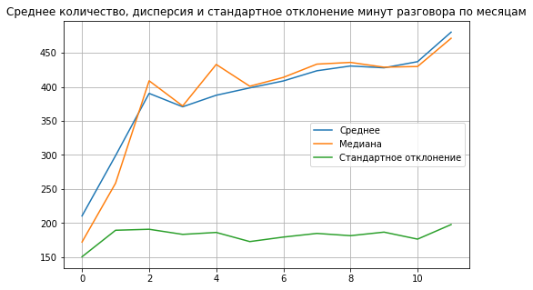

```python
data_calls_pivot_smart_mean = []
data_calls_pivot_smart_median = []
data_calls_pivot_smart_std = []
for i in range(1,13):
    data_calls_pivot_smart_mean.append(data_calls_pivot_smart[data_calls_pivot_smart[i] != 0][i].mean())
    data_calls_pivot_smart_median.append(data_calls_pivot_smart[data_calls_pivot_smart[i] != 0][i].median())
    data_calls_pivot_smart_std.append(np.std(data_calls_pivot_smart[data_calls_pivot_smart[i] != 0][i]))
plt.figure(figsize=(8, 5))
plt.plot(data_calls_pivot_smart_mean, label = 'Cреднее')
plt.plot(data_calls_pivot_smart_median, label = 'Медиана')
plt.plot(data_calls_pivot_smart_std, label = 'Стандартное отклонение')
plt.title('Cреднее количество, дисперсия и стандартное отклонение минут разговора по месяцам')
plt.legend()
plt.grid(True)
```

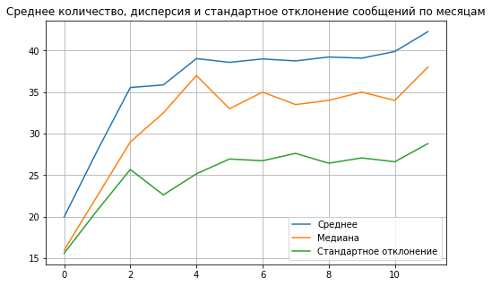

```python
data_messages_pivot_smart_mean = []
data_messages_pivot_smart_median = []
data_messages_pivot_smart_std = []
for i in range(1,13):
    data_messages_pivot_smart_mean.append(data_messages_pivot_smart[data_messages_pivot_smart[i] != 0][i].mean())
    data_messages_pivot_smart_median.append(data_messages_pivot_smart[data_messages_pivot_smart[i] != 0][i].median())
    data_messages_pivot_smart_std.append(np.std(data_messages_pivot_smart[data_messages_pivot_smart[i] != 0][i]))
plt.figure(figsize=(8, 5))
plt.plot(data_messages_pivot_smart_mean, label = 'Cреднее')
plt.plot(data_messages_pivot_smart_median, label = 'Медиана')
plt.plot(data_messages_pivot_smart_std, label = 'Стандартное отклонение')
plt.title('Cреднее количество, дисперсия и стандартное отклонение сообщений по месяцам')
plt.legend()
plt.grid(True)
```

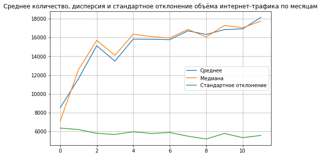

```python
data_internet_pivot_smart_mean = []
data_internet_pivot_smart_median = []
data_internet_pivot_smart_std = []
for i in range(1,13):
    data_internet_pivot_smart_mean.append(data_internet_pivot_smart[data_internet_pivot_smart[i] != 0][i].mean())
    data_internet_pivot_smart_median.append(data_internet_pivot_smart[data_internet_pivot_smart[i] != 0][i].median())
    data_internet_pivot_smart_std.append(np.std(data_internet_pivot_smart[data_internet_pivot_smart[i] != 0][i]))
plt.figure(figsize=(8, 5))
plt.plot(data_internet_pivot_smart_mean, label = 'Cреднее')
plt.plot(data_internet_pivot_smart_median, label = 'Медиана')
plt.plot(data_internet_pivot_smart_std, label = 'Стандартное отклонение')
plt.title('Cреднее количество, дисперсия и стандартное отклонение объёма интернет-трафика по месяцам')
plt.legend()
plt.grid(True)
```

Проделаем тоже самое для пользователей тарифа «Ультра».

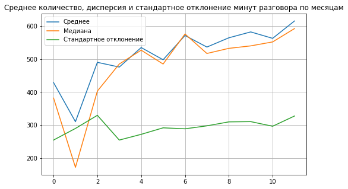

```python
data_calls_pivot_ultra_mean = []
data_calls_pivot_ultra_median = []
data_calls_pivot_ultra_std = []
for i in range(1,13):
    data_calls_pivot_ultra_mean.append(data_calls_pivot_ultra[data_calls_pivot_ultra[i] != 0][i].mean())
    data_calls_pivot_ultra_median.append(data_calls_pivot_ultra[data_calls_pivot_ultra[i] != 0][i].median())
    data_calls_pivot_ultra_std.append(np.std(data_calls_pivot_ultra[data_calls_pivot_ultra[i] != 0][i]))
plt.figure(figsize=(8, 5))
plt.plot(data_calls_pivot_ultra_mean, label = 'Cреднее')
plt.plot(data_calls_pivot_ultra_median, label = 'Медиана')
plt.plot(data_calls_pivot_ultra_std, label = 'Стандартное отклонение')
plt.title('Cреднее количество, дисперсия и стандартное отклонение минут разговора по месяцам')
plt.legend()
plt.grid(True)
```

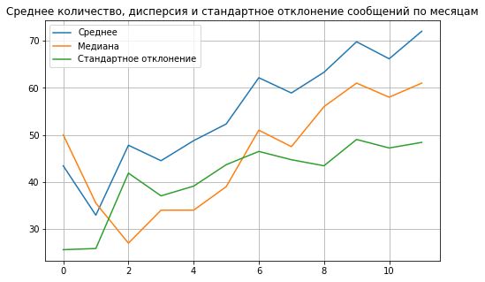

```python
data_messages_pivot_ultra_mean = []
data_messages_pivot_ultra_median = []
data_messages_pivot_ultra_std = []
for i in range(1,13):
    data_messages_pivot_ultra_mean.append(data_messages_pivot_ultra[data_messages_pivot_ultra[i] != 0][i].mean())
    data_messages_pivot_ultra_median.append(data_messages_pivot_ultra[data_messages_pivot_ultra[i] != 0][i].median())
    data_messages_pivot_ultra_std.append(np.std(data_messages_pivot_ultra[data_messages_pivot_ultra[i] != 0][i]))
plt.figure(figsize=(8, 5))
plt.plot(data_messages_pivot_ultra_mean, label = 'Cреднее')
plt.plot(data_messages_pivot_ultra_median, label = 'Медиана')
plt.plot(data_messages_pivot_ultra_std, label = 'Стандартное отклонение')
plt.title('Cреднее количество, дисперсия и стандартное отклонение сообщений по месяцам')
plt.legend()
plt.grid(True)
```

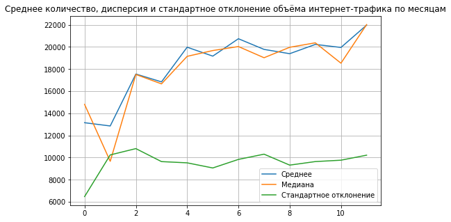

```python
data_internet_pivot_ultra_mean = []
data_internet_pivot_ultra_median = []
data_internet_pivot_ultra_std = []
for i in range(1,13):
    data_internet_pivot_ultra_mean.append(data_internet_pivot_ultra[data_internet_pivot_ultra[i] != 0][i].mean())
    data_internet_pivot_ultra_median.append(data_internet_pivot_ultra[data_internet_pivot_ultra[i] != 0][i].median())
    data_internet_pivot_ultra_std.append(np.std(data_internet_pivot_ultra[data_internet_pivot_ultra[i] != 0][i]))
plt.figure(figsize=(8, 5))
plt.plot(data_internet_pivot_ultra_mean, label = 'Cреднее')
plt.plot(data_internet_pivot_ultra_median, label = 'Медиана')
plt.plot(data_internet_pivot_ultra_std, label = 'Стандартное отклонение')
plt.title('Cреднее количество, дисперсия и стандартное отклонение объёма интернет-трафика по месяцам')
plt.legend()
plt.grid(True)
```

Построим гистограммы количества минут разговора по каждому месяцу для тарифов «Смарт» (слева) и «Ультра» (справа). Идеально было бы создать анимированную гистограмму для экономии места, но я не смог и время поджимало.

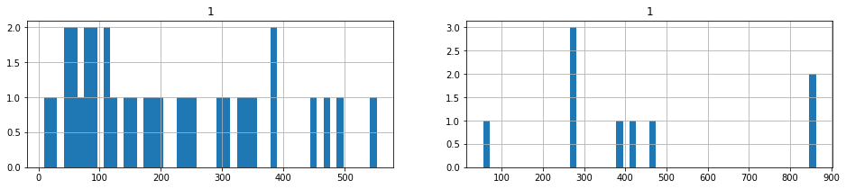

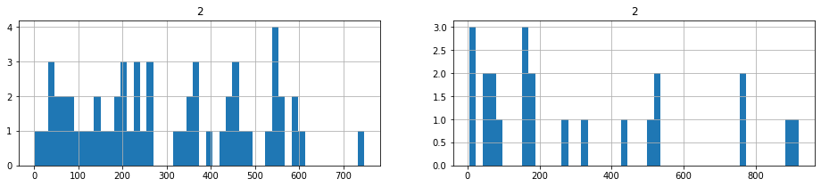

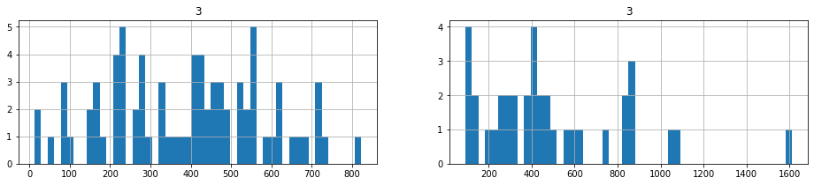

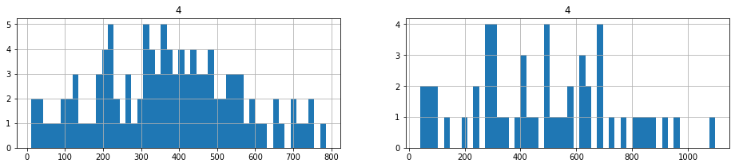

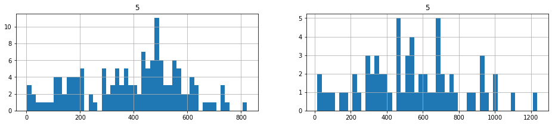

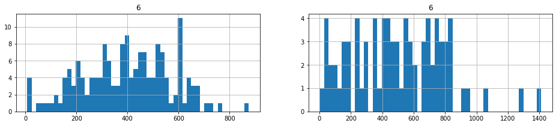

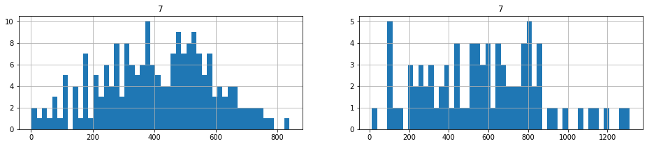

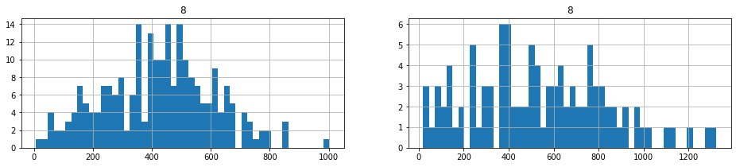

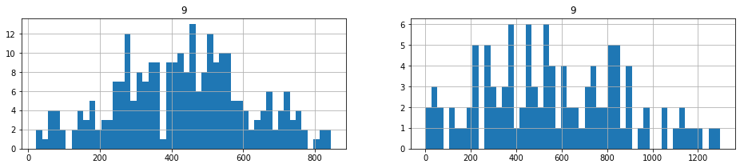

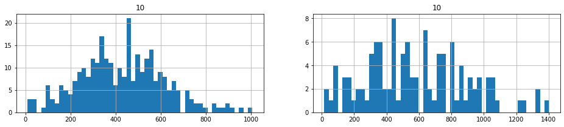

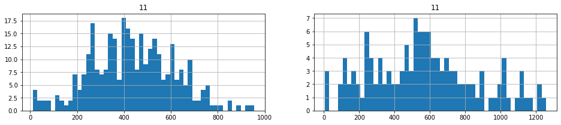

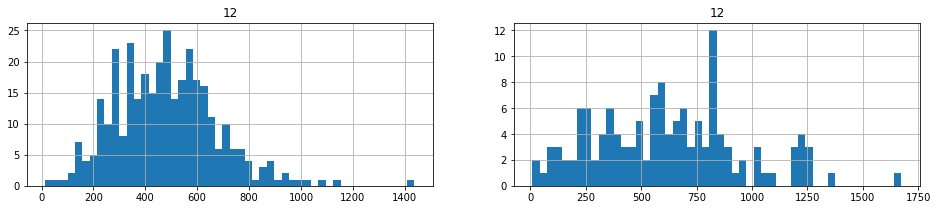

```python
for i in range(1,13):
    plt.figure(figsize=(16, 3))
    plt.subplot(1, 2, 1)
    data_calls_pivot_smart[data_calls_pivot_smart[i] != 0][i].hist(bins=50)
    plt.title(i)
    plt.subplot(1, 2, 2)
    data_calls_pivot_ultra[data_calls_pivot_ultra[i] != 0][i].hist(bins=50)
    plt.title(i)
```

Построим гистограммы количества сообщений по каждому месяцу для тарифов «Смарт» (слева) и «Ультра» (справа).

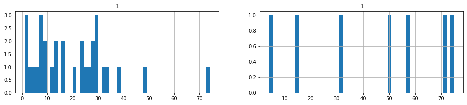

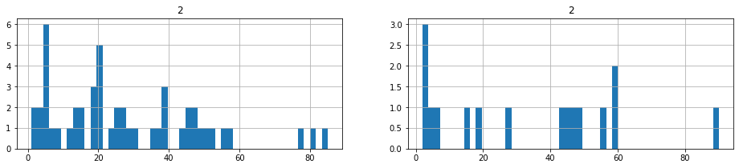

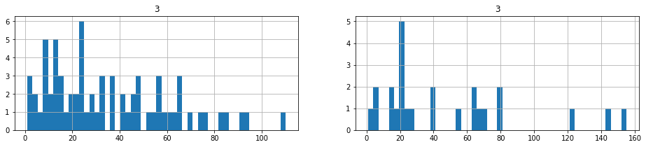

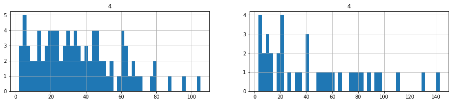

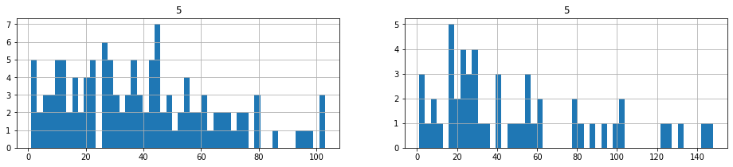

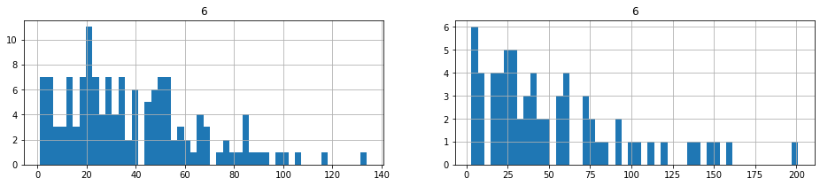

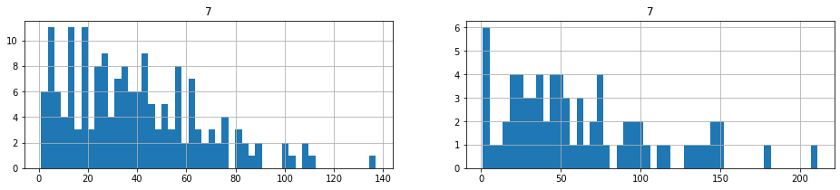

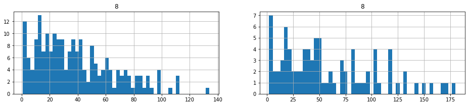

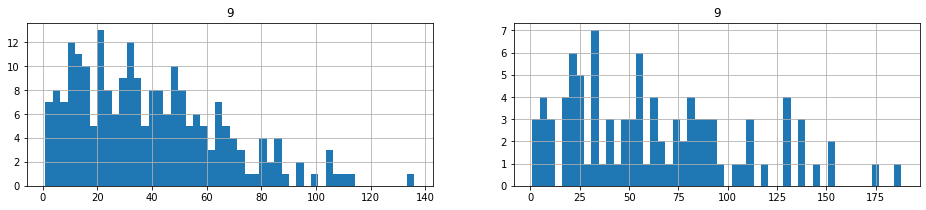

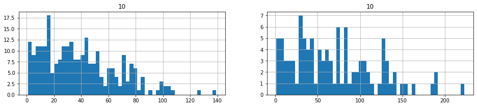

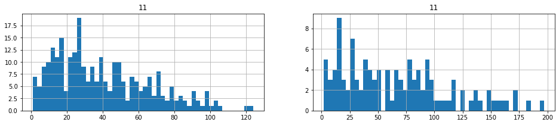

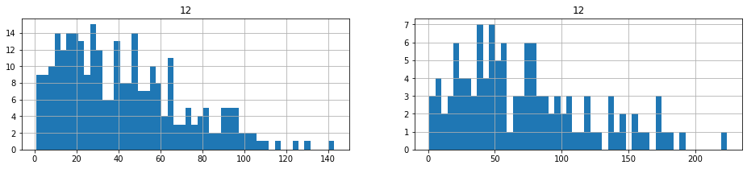

```python
for i in range(1,13):
    plt.figure(figsize=(16, 3))
    plt.subplot(1, 2, 1)
    data_messages_pivot_smart[data_messages_pivot_smart[i] != 0][i].hist(bins=50)
    plt.title(i)
    plt.subplot(1, 2, 2)
    data_messages_pivot_ultra[data_messages_pivot_ultra[i] != 0][i].hist(bins=50)
    plt.title(i)
```

Построим гистограммы объёма интернет-трафика по каждому месяцу для тарифов «Смарт» (слева) и «Ультра» (справа).